# Stat184 Final Project - Yuzhe Wang

Dec 13,2020

## Guiding Question:

I am a fan of NBA games.So I decided to expolore the NBA players dataset.Recently, there has been speculation that the way NBA basketball is playing is changing. Specifically, from the perspective of more teams than in previous years, the game has become more offensive and the game has accelerated. Especially there are more three-pointers existing in many games. I will dive into the 2014-2018 team data and the historical player data of each NBA player ever played in to try to determine whether this is a reality.

### data sources

-Where did you find them? kaggle datasource1: https://www.kaggle.com/ionaskel/nba-games-stats-from-2014-to-2018 -Who collected/maintains them? Ionas Kelepouris -When? 3 years ago -Why were they originally collected? Understand the impact of every statistic category in wins and losses. kaggle datasource2: https://www.kaggle.com/drgilermo/nba-players-stats?select=Seasons_Stats.csv -Who collected/maintains them? Omri Goldstein -When? 3 years ago -Why were they originally collected? The data-set contains aggregate individual statistics for 67 NBA seasons since 1950

### Imorting and Inspecting Datasets

```r
#Data Access
NBAData <- read.csv("nba.games.stats.csv") #Data Source 1
AllTime <- read.csv("Seasons_Stats.csv")   #Data Source 2
head(NBAData)  #DataAccess
```

|  | X | Team | Game | Date | Home | Opponent | WINorLOSS | TeamPoints | OpponentPoints | FieldGoals | FieldGoalsAttempted | FieldGoals. | X3PointShots | X3PointShotsAttempted | X3PointShots. | FreeThrows | FreeThrowsAttempted | FreeThrows. | OffRebounds | TotalRebounds | Assists | Steals | Blocks | Turnovers | TotalFouls | Opp.FieldGoals | Opp.FieldGoalsAttempted | Opp.FieldGoals. | Opp.3PointShots | … |
| --- | --- | --- | --- | --- | --- | --- | --- | --- | --- | --- | --- | --- | --- | --- | --- | --- | --- | --- | --- | --- | --- | --- | --- | --- | --- | --- | --- | --- | --- | --- |
| 1 | 1 | ATL | 1 | 2014-10-29 | Away | TOR | L | 102 | 109 | 40 | 80 | 0.500 | 13 | 22 | 0.591 | 9 | 17 | 0.529 | 10 | 42 | 26 | 6 | 8 | 17 | 24 | 37 | 90 | 0.411 | 8 | … |
| 2 | 2 | ATL | 2 | 2014-11-01 | Home | IND | W | 102 | 92 | 35 | 69 | 0.507 | 7 | 20 | 0.350 | 25 | 33 | 0.758 | 3 | 37 | 26 | 10 | 6 | 12 | 20 | 31 | 81 | 0.383 | 12 | … |
| 3 | 3 | ATL | 3 | 2014-11-05 | Away | SAS | L | 92 | 94 | 38 | 92 | 0.413 | 8 | 25 | 0.320 | 8 | 11 | 0.727 | 10 | 37 | 26 | 14 | 5 | 13 | 25 | 31 | 69 | 0.449 | 5 | … |
| 4 | 4 | ATL | 4 | 2014-11-07 | Away | CHO | L | 119 | 122 | 43 | 93 | 0.462 | 13 | 33 | 0.394 | 20 | 26 | 0.769 | 7 | 38 | 28 | 8 | 3 | 19 | 33 | 48 | 97 | 0.495 | 6 | … |
| 5 | 5 | ATL | 5 | 2014-11-08 | Home | NYK | W | 103 | 96 | 33 | 81 | 0.407 | 9 | 22 | 0.409 | 28 | 36 | 0.778 | 12 | 41 | 18 | 10 | 5 | 8 | 17 | 40 | 84 | 0.476 | 8 | … |
| 6 | 6 | ATL | 6 | 2014-11-10 | Away | NYK | W | 91 | 85 | 27 | 71 | 0.380 | 10 | 27 | 0.370 | 27 | 28 | 0.964 | 9 | 38 | 20 | 7 | 3 | 15 | 16 | 36 | 83 | 0.434 | 6 | … |

```r
nrow(NBAData)  #DataAccess
```

```
[1] 9801
```

```r
head(AllTime)
```

|  | X | Year | Player | Pos | Age | Tm | G | GS | MP | PER | TS. | X3PAr | FTr | ORB. | DRB. | TRB. | AST. | STL. | BLK. | TOV. | USG. | blanl | OWS | DWS | WS | WS.48 | blank2 | OBPM | DBPM | … |
| --- | --- | --- | --- | --- | --- | --- | --- | --- | --- | --- | --- | --- | --- | --- | --- | --- | --- | --- | --- | --- | --- | --- | --- | --- | --- | --- | --- | --- | --- | --- |
| 1 | 0 | 1950 | Curly Armstrong | G-F | 31 | FTW | 63 | NA | NA | NA | 0.368 | NA | 0.467 | NA | NA | NA | NA | NA | NA | NA | NA | NA | -0.1 | 3.6 | 3.5 | NA | NA | NA | NA | … |
| 2 | 1 | 1950 | Cliff Barker | SG | 29 | INO | 49 | NA | NA | NA | 0.435 | NA | 0.387 | NA | NA | NA | NA | NA | NA | NA | NA | NA | 1.6 | 0.6 | 2.2 | NA | NA | NA | NA | … |
| 3 | 2 | 1950 | Leo Barnhorst | SF | 25 | CHS | 67 | NA | NA | NA | 0.394 | NA | 0.259 | NA | NA | NA | NA | NA | NA | NA | NA | NA | 0.9 | 2.8 | 3.6 | NA | NA | NA | NA | … |
| 4 | 3 | 1950 | Ed Bartels | F | 24 | TOT | 15 | NA | NA | NA | 0.312 | NA | 0.395 | NA | NA | NA | NA | NA | NA | NA | NA | NA | -0.5 | -0.1 | -0.6 | NA | NA | NA | NA | … |
| 5 | 4 | 1950 | Ed Bartels | F | 24 | DNN | 13 | NA | NA | NA | 0.308 | NA | 0.378 | NA | NA | NA | NA | NA | NA | NA | NA | NA | -0.5 | -0.1 | -0.6 | NA | NA | NA | NA | … |
| 6 | 5 | 1950 | Ed Bartels | F | 24 | NYK | 2 | NA | NA | NA | 0.376 | NA | 0.750 | NA | NA | NA | NA | NA | NA | NA | NA | NA | 0.0 | 0.0 | 0.0 | NA | NA | NA | NA | … |

```r
nrow(AllTime)
```

```
[1] 24610
```

### Libraries Used

```r
#Libraries
library(dplyr)
library(tidyverse)
library(lubridate)
```

### User-defined Function

```r
#determine if a team is East or West(custom settings)
whichConf <- function(team){
  if (team %in% c("ATL", "BOS", "BRK" ,"CHI", "CHO",
                  "CLE", "DET", "IND", "MIA", "MIL",
                  "NYK", "ORL", "PHI", "TOR", "WAS")){
    return("East")
  }
  else {
    return("West")
  }
} #Wrangling 4 (Control flow with if-else statement)
```

### Data Wrangling

```r
#Visualizing Change of amounts of threes taken per year for each team
ModifiedNBA <-
NBAData %>%
  mutate(Date = year(lubridate::ymd(Date))) %>%  #Wrangling1
  group_by(Team,Date) %>%
  summarise(AvgThree = mean(X3PointShotsAttempted))  #Wrangling2
NewModified <-
  ModifiedNBA %>%
  mutate(Conf = whichConf(Team)) #Wrangling3 (Using the user-defined function)
```

### Data Visualization (1)

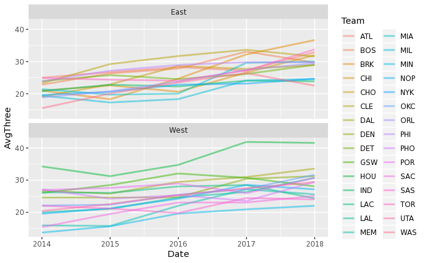

```r
#Visualizing Change of amounts of threes taken per year for each team
ModifiedNBA <-
NBAData %>%
  mutate(Date = year(lubridate::ymd(Date))) %>%  #Wrangling1
  group_by(Team,Date) %>%
  summarise(AvgThree = mean(X3PointShotsAttempted))  #Wrangling2
NewModified <-
  ModifiedNBA %>%
  mutate(Conf = whichConf(Team)) #Wrangling3 (Using the user-defined function)
NewModified %>%
  ggplot(aes(x = Date, y = AvgThree, group = Team)) +
  geom_line(size = 1, alpha = 0.5, aes(color = Team)) +
  facet_wrap(~Conf, dir = "v") #Visualization 1 and 2
```

### Data Visualization (2)

The three point line was not introduced until 1979, so I will only be looking at data starting from that point for my historic player data. This is considered by many to be a ‘turning point’ in NBA history.

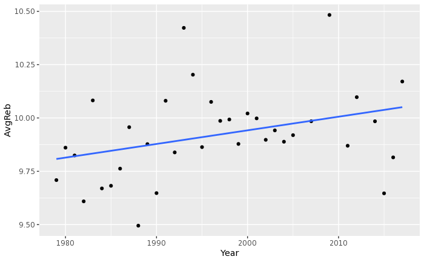

```r
HistData <-
AllTime %>%
  filter(Year >= 1979)
HistRebounds <-
HistData %>%
  group_by(Year) %>%
  summarise(AvgReb = mean(TRB.))
HistRebounds %>%
  ggplot(aes(x = Year, y = AvgReb)) +
  geom_point(na.rm = TRUE) +
  geom_smooth(method = 'lm', se = FALSE, na.rm = TRUE) #Visualization3
```

### Linear Regression Analysis

```r
linearMod <- lm(FieldGoalsAttempted ~ TotalRebounds, data = NBAData) #DataWrangling5
summary(linearMod)
```

```
Call:
lm(formula = FieldGoalsAttempted ~ TotalRebounds, data = NBAData)

Residuals:
    Min      1Q  Median      3Q     Max
-22.294  -4.350  -0.127   4.178  33.903

Coefficients:
              Estimate Std. Error t value Pr(>|t|)
(Intercept)   64.35287    0.44747  143.82   <2e-16 ***
TotalRebounds  0.47214    0.01017   46.42   <2e-16 ***
---
Signif. codes:  0 ‘***’ 0.001 ‘**’ 0.01 ‘*’ 0.05 ‘.’ 0.1 ‘ ’ 1

Residual standard error: 6.46 on 9799 degrees of freedom
Multiple R-squared:  0.1803,    Adjusted R-squared:  0.1802
F-statistic:  2155 on 1 and 9799 DF,  p-value: < 2.2e-16
```

In the code block above, I ran a linear regression model to determine whether the total rebounds had an effect on the goal that was trying to support my alignment from the previous chart. Based on the above summary, the significance test of whether total rebounds have an effect on the attempted shot goal shows that there is indeed a significant relationship between the above variables.